# Assignment_7_Data_624

### (f) Explore the relationships between each of the top predictors and the response. How could this information be helpful in improving yield in future runs of the manufacturing process?

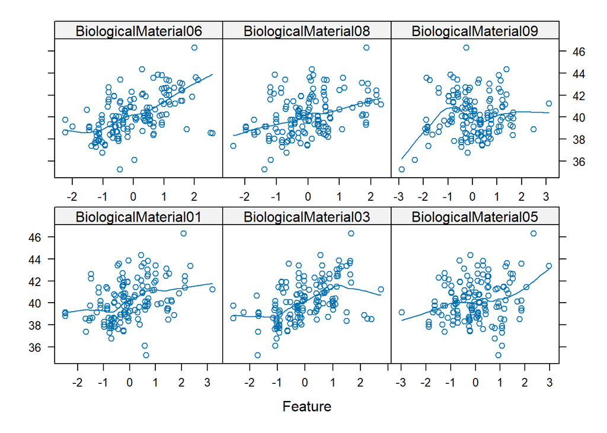

```r
# Calculating importance specifically for the Chemical Manufacturing Model
importance_chem <- varImp(pls_model_chem)

# Getting the names of the top 6 predictors that exist in final dataset
# This prevents the "undefined columns" error
top_6_chem <- rownames(importance_chem$importance)[1:6]

# Create the feature plot to explore relationships
library(caret)
featurePlot(x = train_x_final[, top_6_chem],
            y = train_y,
            plot = "scatter",
            type = c("p", "smooth"),
            span = 0.5,
            layout = c(3, 2))
```

**Interpretation**

The scatter plots show the trend between predictors and yield. For example, BiologicalMaterial06 and BiologicalMaterial01 show a positive linear relationship, meaning that as these values increase, yield generally increases. Plant managers can target higher levels of these specific materials to boost production.

Some plots, like BiologicalMaterial09, show a steep initial increase that levels off. This indicates a diminishing return where increasing the material beyond a certain point no longer adds significant yield, helping avoid wasted resources.

Some variables show a lot of scatter (wide spread of points). This tells the team that those specific factors are less reliable for prediction than the ones where the blue trend line clearly cuts through the data.

**Summary of Results**

The model achieved its best results with 4 components, yielding an RMSE of 1.176.

The drop from 61.3% explanation (training) to 39.9% (test) shows the model captures some batch-specific noise.